# Pythagorean Wins

## Getting the Data

Game results from Baseball Reference via the **baseballr** package provides an easy way to gather standings information for each team. The **Lahman** package is another option for exploring standings and runs data for a Pythagorean wins estimate, but data is only available through the 2016 season. By using the function **team_results_bref()**, I was able to gather game log information for each team over the past five seasons (2014 to 2018). In order to loop through the **team_results_bref()** function, I first had to extract each team’s Baseball Reference ID which I did rely on **Lahman** for. All combinations of team IDs and seasons were input into a data frame in order to loop through the function, storing the results of each team for each season in a list.

|  | Team IDs | Season |
| --- | --- | --- |
| 44 | LAD | 2015 |
| 118 | TEX | 2017 |
| 61 | ARI | 2016 |
| 130 | DET | 2018 |
| 138 | NYY | 2018 |

When running through the scraping function from **baseballr** a list is returned. Each element of the list contains game log information for each team and for each season between 2014 and 2018.

Here’s an example of what is returned:

| Gm | Date | Tm | H_A | Opp | Result | R | RA | Record | GB | Year |
| --- | --- | --- | --- | --- | --- | --- | --- | --- | --- | --- |
| 1 | Saturday, Mar 22 | ARI | H | LAD | L | 1 | 3 | 0-1 | 1.0 | 2014 |
| 2 | Sunday, Mar 23 | ARI | H | LAD | L | 5 | 7 | 0-2 | 2.0 | 2014 |
| 3 | Monday, Mar 31 | ARI | H | SFG | L | 8 | 9 | 0-3 | 2.0 | 2014 |
| 4 | Tuesday, Apr 1 | ARI | H | SFG | W | 5 | 4 | 1-3 | 2.0 | 2014 |
| 5 | Wednesday, Apr 2 | ARI | H | SFG | L | 0 | 2 | 1-4 | 3.0 | 2014 |
| 6 | Thursday, Apr 3 | ARI | H | SFG | L | 5 | 8 | 1-5 | 3.5 | 2014 |

With game log information now available, the next step was to aggregate the information for each team and each season. Once this aggregation was complete, the number of wins, losses, runs scored, and runs allowed for each team was available for the last 5 seasons.

Using this data, linear regression was run to determine which exponent provides the best-fit for the Pythagorean wins formula. The premise is to predict the team’s win percentage/win total using only the number of runs scored and runs allowed. In a modeling setting, in order to return the best-fit exponent the dependent variable becomes the natural log of the team’s win ratio (*log(wins/losses)*) while the independent variable is taken as the natural log of the team’s runs to runs allowed (*log(runs/runs_allowed)*).

```r
pythag_fit <- lm(logWratio ~ 0 + logRratio, data = pythag_data)
```

It was determined that the exponent providing the best-fit for the last 5 seasons was 1.71, a large difference than from Bill James’ original exponent of 2.

Applying the Pythagorean formula for the past five years with an exponent of 1.71 provides a mean absolute error of about 3 games. Thus, we can expect predictions to typically be within 3 games of the actual results for that season. The plot below indicates where the Chicago White Sox have fallen relative to its Pythagorean wins estimate over the last 5 years.

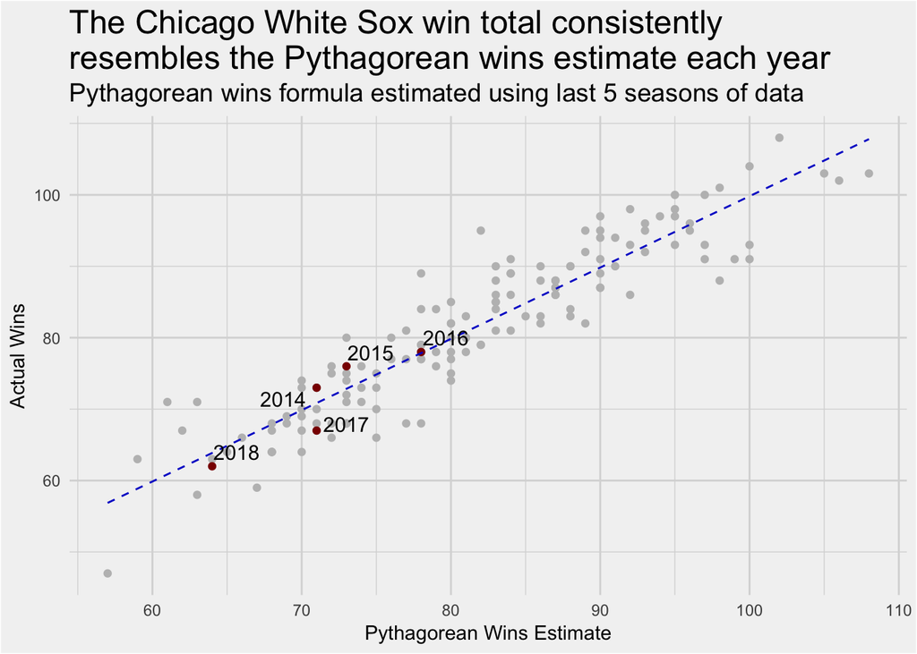

In 2016, the team’s actual number of wins and its Pythagorean estimate agreed on 78 wins. However, the Pythagorean expectation underestimated the number of wins in 2014 and 2015 by 2 and 3, respectively, while it overestimated the number of wins for the two most recent seasons by 4 and 2, respectively. Differences between the Pythagorean estimate and the actual number of wins could potentially be attributed to how the team has performed in one-run games. The table below shows the team’s record in one-run games over the last five seasons. While the Pythagorean estimates are off by only a few games, we see that the when the team has underperformed the estimate, its record in one-run games is typically worse.

| Season | Record (one-run games) |
| --- | --- |
| 2014 | 28-24 |
| 2015 | 29-30 |
| 2016 | 23-29 |
| 2017 | 21-23 |
| 2018 | 15-25 |